# Taller 6

Métodos Computacionales para Políticas Públicas - URosario

**Entrega: viernes 30-sep-2016 11:59 PM**

**[Camila Valencia]**  
[camila.valencia@urosario.edu.co]

## Instrucciones:

- Guarde una copia de este *Jupyter Notebook* en su computador, idealmente en una carpeta destinada al material del curso.
- Modifique el nombre del archivo del *notebook*, agregando al final un guión inferior y su nombre y apellido, separados estos últimos por otro guión inferior. Por ejemplo, mi *notebook* se llamaría: mcpp_taller6_santiago_matallana
- Marque el *notebook* con su nombre y e-mail en el bloque verde arriba. Reemplace el texto "[Su nombre acá]" con su nombre y apellido. Similar para su e-mail.
- Desarrolle la totalidad del taller sobre este *notebook*, insertando las celdas que sea necesario debajo de cada pregunta. Haga buen uso de las celdas para código y de las celdas tipo *markdown* según el caso.
- Recuerde salvar periódicamente sus avances.
- Cuando termine el taller:
  1. Descárguelo en PDF. Si tiene algún problema con la conversión, descárguelo en HTML.
  2. Suba todos los archivos a su repositorio en GitHub, en una carpeta destinada exclusivamente para este taller, antes de la fecha y hora límites.

(Todos los ejercicios tienen el mismo valor.)

### Resuelva las partes 1 y 3 de [este documento](http://www.math.pitt.edu/~sussmanm/3040Summer14/exercisesII.pdf).

#### Numpy practice

Start up Python (best to use Spyder) and use it to answer the following ques- tions. Use the following imports:

```python
import numpy as np
import scipy.linalg as la
import matplotlib.pyplot as plt
```

Choose a value and set the variable x to that value.

```python
x=55
x
```

```
55
```

```python
np.square(x)
```

```
3025
```

Choose an angle and set the variable theta to its value (a number).

```python
theta = 45
theta
```

```
45
```

What is sin (theta)? cos(theta)? Angles can be measured in degrees or radians. Which of these are being used used?

Los input de las funciones seno y coseno son radianes, lo cual si tengo grados puedo usar la funcion degree2rad.()

```python
pi= np.pi
theta= np.deg2rad(theta)
theta
```

```
0.78539816339744828
```

```python
np.sin(theta)
```

```
0.70710678118654757
```

```python
np.cos(theta)
```

```
0.70710678118654757
```

Use the np.linspace function to create a row vector called meshPoints containing exactly 500 values with values evenly spaced between -1 and 1.

```python
meshPoints= np.linspace(-1,1,500)
meshPoints
```

```
array([-1.        , -0.99599198, -0.99198397, -0.98797595, -0.98396794,
       -0.97995992, -0.9759519 , -0.97194389, -0.96793587, -0.96392786,
       -0.95991984, -0.95591182, -0.95190381, -0.94789579, -0.94388778,
       -0.93987976, -0.93587174, -0.93186373, -0.92785571, -0.9238477 ,
       -0.91983968, -0.91583166, -0.91182365, -0.90781563, -0.90380762,
       -0.8997996 , -0.89579158, -0.89178357, -0.88777555, -0.88376754,
       -0.87975952, -0.8757515 , -0.87174349, -0.86773547, -0.86372745,
       -0.85971944, -0.85571142, -0.85170341, -0.84769539, -0.84368737,
       -0.83967936, -0.83567134, -0.83166333, -0.82765531, -0.82364729,
       -0.81963928, -0.81563126, -0.81162325, -0.80761523, -0.80360721,
       -0.7995992 , -0.79559118, -0.79158317, -0.78757515, -0.78356713,
       -0.77955912, -0.7755511 , -0.77154309, -0.76753507, -0.76352705,
       -0.75951904, -0.75551102, -0.75150301, -0.74749499, -0.74348697,
       -0.73947896, -0.73547094, -0.73146293, -0.72745491, -0.72344689,
       -0.71943888, -0.71543086, -0.71142285, -0.70741483, -0.70340681,
       -0.6993988 , -0.69539078, -0.69138277, -0.68737475, -0.68336673,
       -0.67935872, -0.6753507 , -0.67134269, -0.66733467, -0.66332665,
       -0.65931864, -0.65531062, -0.65130261, -0.64729459, -0.64328657,
       -0.63927856, -0.63527054, -0.63126253, -0.62725451, -0.62324649,
       -0.61923848, -0.61523046, -0.61122244, -0.60721443, -0.60320641,
       -0.5991984 , -0.59519038, -0.59118236, -0.58717435, -0.58316633,
       -0.57915832, -0.5751503 , -0.57114228, -0.56713427, -0.56312625,
       -0.55911824, -0.55511022, -0.5511022 , -0.54709419, -0.54308617,
       -0.53907816, -0.53507014, -0.53106212, -0.52705411, -0.52304609,
       -0.51903808, -0.51503006, -0.51102204, -0.50701403, -0.50300601,
       -0.498998  , -0.49498998, -0.49098196, -0.48697395, -0.48296593,
       -0.47895792, -0.4749499 , -0.47094188, -0.46693387, -0.46292585,
       -0.45891784, -0.45490982, -0.4509018 , -0.44689379, -0.44288577,
       -0.43887776, -0.43486974, -0.43086172, -0.42685371, -0.42284569,
       -0.41883768, -0.41482966, -0.41082164, -0.40681363, -0.40280561,
       -0.3987976 , -0.39478958, -0.39078156, -0.38677355, -0.38276553,
       -0.37875752, -0.3747495 , -0.37074148, -0.36673347, -0.36272545,
       -0.35871743, -0.35470942, -0.3507014 , -0.34669339, -0.34268537,
       -0.33867735, -0.33466934, -0.33066132, -0.32665331, -0.32264529,
       -0.31863727, -0.31462926, -0.31062124, -0.30661323, -0.30260521,
       -0.29859719, -0.29458918, -0.29058116, -0.28657315, -0.28256513,
       -0.27855711, -0.2745491 , -0.27054108, -0.26653307, -0.26252505,
       -0.25851703, -0.25450902, -0.250501  , -0.24649299, -0.24248497,
       -0.23847695, -0.23446894, -0.23046092, -0.22645291, -0.22244489,
       -0.21843687, -0.21442886, -0.21042084, -0.20641283, -0.20240481,
```

[output cut: 45 more lines]

```
        0.70340681,  0.70741483,  0.71142285,  0.71543086,  0.71943888,
        0.72344689,  0.72745491,  0.73146293,  0.73547094,  0.73947896,
        0.74348697,  0.74749499,  0.75150301,  0.75551102,  0.75951904,
        0.76352705,  0.76753507,  0.77154309,  0.7755511 ,  0.77955912,
        0.78356713,  0.78757515,  0.79158317,  0.79559118,  0.7995992 ,
        0.80360721,  0.80761523,  0.81162325,  0.81563126,  0.81963928,
        0.82364729,  0.82765531,  0.83166333,  0.83567134,  0.83967936,
        0.84368737,  0.84769539,  0.85170341,  0.85571142,  0.85971944,
        0.86372745,  0.86773547,  0.87174349,  0.8757515 ,  0.87975952,
        0.88376754,  0.88777555,  0.89178357,  0.89579158,  0.8997996 ,
        0.90380762,  0.90781563,  0.91182365,  0.91583166,  0.91983968,
        0.9238477 ,  0.92785571,  0.93186373,  0.93587174,  0.93987976,
        0.94388778,  0.94789579,  0.95190381,  0.95591182,  0.95991984,
        0.96392786,  0.96793587,  0.97194389,  0.9759519 ,  0.97995992,
        0.98396794,  0.98797595,  0.99198397,  0.99599198,  1.        ])
```

```python
meshPoints[54]
```

```
-0.78356713426853708
```

Produce a plot of a sinusoid on the interval [-1; 1] using the command

```python
import matplotlib.pylab as plt
%matplotlib inline
```

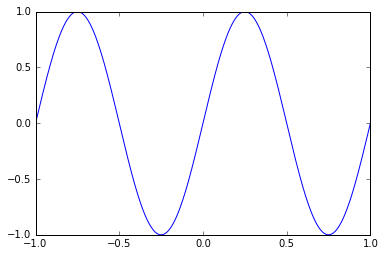

```python
plt.plot(meshPoints,np.sin(2*pi*meshPoints));
plt.savefig('sinmeshPoints.png')
```

### Plotting

Use matplotlib.pyplot.plot to produce a plot of the functions f(x) = e(-x/10) sin(pix) and g(x) = xe(-x/3) over the interval [0; 10]. Include labels for the x- and y-axes, and a legend explaining which line is which plot. Save the plot as a .jpg (\Jpeg") file and send me a copy with your work.

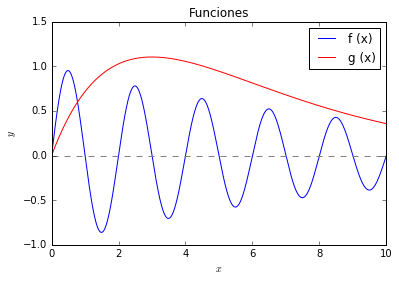

```python
import matplotlib.pylab as plt
%matplotlib inline
x = np.linspace(0, 10, 1000)
pi= np.pi
f= np.exp((-x)/10)*np.sin(pi*x)
g= x* np.exp((-x)/3)

plt.title('Funciones')
plt.xlabel('$x$')
plt.ylabel('$y$')
plt.plot(x, f, color="blue", label="f (x)")
plt.plot(x,g , color="red", label="g (x)")
plt.axhline(0, color="gray", linestyle="--")
plt.legend();
plt.savefig('funciones.jpg')
```

### Plotting

The shape of a limacon can be defined parametrically as:

r = r0 + cos(theta)

x = r cos(theta)

y = r sin (theta)

When r0 = 1, this curve is called a cardioid. Use this definition to plot the shape of a limacon for r0 = 0:8, r0 = 1:0, and r0 = 1:2. Be sure to use enough points that the curve is closed and appears smooth (except for the cusp in the cardioid). Use a legend to identify which curve is which. Save the plot as a .pdf file and send me a copy with your work.

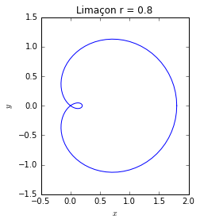

```python
from matplotlib.backends.backend_pdf import PdfPages
pp = PdfPages('limon.pdf')
theta = np.linspace(0, 2*np.pi, 100)
r = 0.8+np.cos(theta)
x1 = r*np.cos(theta)
x2 = r*np.sin(theta)
fig, ax = plt.subplots(1)
plt.plot(x1, x2)
ax.set_aspect(1)
plt.xlabel('$x$')
plt.ylabel('$y$')
plt.title('Limaçon r = 0.8');

plt.savefig(pp, format='pdf')
plt.savefig('limon1.jpg')
```

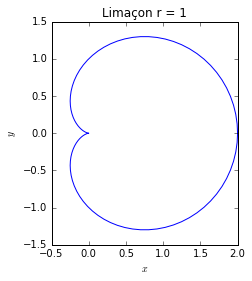

```python
theta = np.linspace(0, 2*np.pi, 100)
r = 1+np.cos(theta)
x1 = r*np.cos(theta)
x2 = r*np.sin(theta)
fig, ax = plt.subplots(1)
plt.plot(x1, x2)
ax.set_aspect(1)
plt.xlabel('$x$')
plt.ylabel('$y$')
plt.title('Limaçon r = 1');
plt.savefig(pp, format='pdf')
plt.savefig('limon2.jpg')
```

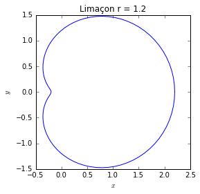

```python
theta = np.linspace(0, 2*np.pi, 100)
r = 1.2+np.cos(theta)
x1 = r*np.cos(theta)
x2 = r*np.sin(theta)
fig, ax = plt.subplots(1)
plot3 = ax.plot(x1, x2)
ax.set_aspect(1)
plt.xlabel('$x$')
plt.ylabel('$y$')
plt.title('Limaçon r = 1.2');
plt.savefig(pp, format='pdf')
plt.savefig('limon3.jpg')
```

```python
pp.close()
```